# Tarea 4 - Modelos Lineales

Shanthal Chavarría

2021-09-30

# Pregunta 1: **[10 puntos]** En este ejercicio vamos a usar la tabla de datos `wine.csv`, que contiene variantes del vino “Vinho Verde”. Los datos incluyen variables de pruebas fisicoquímicas y sensoriales realizadas a dicho vino.

Para esto realice lo siguiente:

## 1. Cargue la tabla de datos `wine.csv` en `R`.

```r
datos <- read.table("datos/wine.csv", dec = ".", sep = ",",header = T, stringsAsFactors = T)
```

## 2. Usando el comando sample de `R` genere al azar una tabla de testing con una 20 % de los datos y con el resto de los datos genere una tabla de aprendizaje.

```r
filas <- dim(datos)[1]
muestra <- sample(1:filas, floor(filas*0.20))
ttesting <- datos[muestra,]
taprendizaje <- datos[-muestra,]
```

## 3. Usando árboles de Decisión (con `rpart`) genere un modelo predictivo para la tabla de aprendizaje, grafique el árbol obtenido. Pruebe modificar los parámetros del método hasta encontrar el que minimiza el error global.

```r
library(rpart)
library(traineR)
library(rpart.plot)

modelo <- train.rpart(tipo~.,data = taprendizaje, minsplit = 2)
prediccion <- predict(modelo, ttesting, type = 'class')
mc         <- confusion.matrix(newdata = ttesting, prediccion)


Arboles <- general.indexes(mc = mc)
Arboles
```

```
Confusion Matrix:
        prediction
real     blanco tinto
  blanco    965    12
  tinto      19   303

Overall Accuracy: 0.9761
Overall Error:    0.0239

Category Accuracy:

       blanco        tinto
     0.987718     0.940994
```

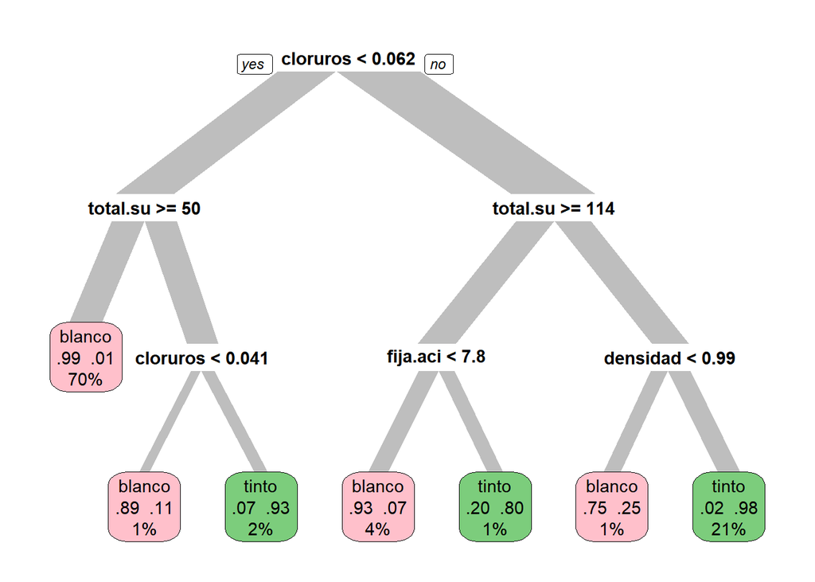

```r
prp(modelo,extra=104,
    branch.type=2,
    box.col=c("pink",
              "palegreen3",
              "cyan")[modelo$frame$yval])
```

## 4. Genere un modelos predictivos para la tabla de aprendizaje usando Bosques Aleatorios, ADABoosting y XGBoosting. Pruebe modificar los parámetros del método hasta encontrar el que minimiza el error global.

### Bosques Aleatorios

```r
modelo.Bosques  <- train.randomForest(formula = tipo~., data = taprendizaje, importance = T)

prediccion.Bosques   <- predict(modelo.Bosques, ttesting, type = "class")
mc           <- confusion.matrix(ttesting, prediccion.Bosques)
BosquesAleatorios <- general.indexes(mc = mc)
BosquesAleatorios
```

```
Confusion Matrix:
        prediction
real     blanco tinto
  blanco    973     4
  tinto       7   315

Overall Accuracy: 0.9915
Overall Error:    0.0085

Category Accuracy:

       blanco        tinto
     0.995906     0.978261
```

### ADABoosting

```r
modelo.ADA  <- train.ada(formula = tipo~.,data = taprendizaje)
prediccion.ADA   <- predict(modelo.ADA, ttesting, type = "class")

mc           <- confusion.matrix(ttesting, prediccion.ADA)
ADABoosting <- general.indexes(mc = mc)
ADABoosting
```

```
Confusion Matrix:
        prediction
real     blanco tinto
  blanco    973     4
  tinto       7   315

Overall Accuracy: 0.9915
Overall Error:    0.0085

Category Accuracy:

       blanco        tinto
     0.995906     0.978261
```

### XGBoosting

```r
modelo.XG <- train.xgboost(formula = tipo~.,
                              data    = taprendizaje,
                              nrounds = 79,
                              verbose = F)
```

```
[13:17:23] WARNING: amalgamation/../src/learner.cc:1095: Starting in XGBoost 1.3.0, the default evaluation metric used with the objective 'binary:logistic' was changed from 'error' to 'logloss'. Explicitly set eval_metric if you'd like to restore the old behavior.
```

```r
prediccion.XG <- predict(modelo.XG, ttesting , type = "class")
mc         <- confusion.matrix(ttesting,prediccion.XG)
XGBoosting <- general.indexes(mc = mc)
XGBoosting
```

```
Confusion Matrix:
        prediction
real     blanco tinto
  blanco    973     4
  tinto       6   316

Overall Accuracy: 0.9923
Overall Error:    0.0077

Category Accuracy:

       blanco        tinto
     0.995906     0.981366
```

## 5. Construya un `DataFrame` de manera que en cada una de las filas aparezca un modelo predictivo y en las columnas aparezcan los índices Precisión Global, Error Global Precisión Positiva (PP), Precisión Negativa (PN), Falsos Positivos (FP), los Falsos Negativos (FN), la Asertividad Positiva (AP) y la Asertividad Negativa (AN). ¿Cuál de los modelos es mejor para estos datos? (incluya todos los métodos que hemos estudiando en el curso).

```r
library(dplyr)
precisiones <- rbind(as.data.frame(Confusion(Arboles$confusion.matrix)),as.data.frame(Confusion(BosquesAleatorios$confusion.matrix)),as.data.frame(Confusion(ADABoosting$confusion.matrix)),as.data.frame(Confusion(XGBoosting$confusion.matrix)))


tablaC <- read.table("Tabla Comparativa wine.csv",dec = ".",sep = "," , header = T)

tablaC <- rbind(precisiones,tablaC)

rownames(tablaC) <- c("Árboles de Decisión", "Bosques Aleatorios", "ADA Boosting", "XG Boosting","rectangular", "triangular", "epanechnikov", "biweight", "triweight", "cos",
"inv", "gaussian","optimal")



tablaC %>%
  arrange(desc(Precision.Global))
```

|  | Precision.Global | Error.Global | Precision.Positiva | Precision.Negativa | Falsos.Positivos | Falsos.Negativos | Asertividad.Positiva | Asertividad.Negativa |
| --- | --- | --- | --- | --- | --- | --- | --- | --- |
| inv | 0.9969231 | 0.003076923 | 0.9905660 | 0.9989817 | 0.001018330 | 0.009433962 | 0.9999968 | 0.9999904 |
| rectangular | 0.9938462 | 0.006153846 | 0.9874214 | 0.9959267 | 0.004073320 | 0.012578616 | 0.9999870 | 0.9999871 |
| triangular | 0.9938462 | 0.006153846 | 0.9874214 | 0.9959267 | 0.004073320 | 0.012578616 | 0.9999870 | 0.9999871 |
| epanechnikov | 0.9938462 | 0.006153846 | 0.9874214 | 0.9959267 | 0.004073320 | 0.012578616 | 0.9999870 | 0.9999871 |
| biweight | 0.9938462 | 0.006153846 | 0.9874214 | 0.9959267 | 0.004073320 | 0.012578616 | 0.9999870 | 0.9999871 |
| triweight | 0.9938462 | 0.006153846 | 0.9874214 | 0.9959267 | 0.004073320 | 0.012578616 | 0.9999870 | 0.9999871 |
| cos | 0.9938462 | 0.006153846 | 0.9874214 | 0.9959267 | 0.004073320 | 0.012578616 | 0.9999870 | 0.9999871 |
| gaussian | 0.9938462 | 0.006153846 | 0.9874214 | 0.9959267 | 0.004073320 | 0.012578616 | 0.9999870 | 0.9999871 |
| optimal | 0.9938462 | 0.006153846 | 0.9874214 | 0.9959267 | 0.004073320 | 0.012578616 | 0.9999870 | 0.9999871 |
| XG Boosting | 0.9923018 | 0.007698229 | 0.9813665 | 0.9959058 | 0.004094166 | 0.018633540 | 0.9999870 | 0.9999808 |

[output cut: 3 more lines]

```r
write.csv(tablaC,"Tabla Comparativa wine2.csv", row.names = FALSE)
tablaC
```

|  | Precision.Global | Error.Global | Precision.Positiva | Precision.Negativa | Falsos.Positivos | Falsos.Negativos | Asertividad.Positiva | Asertividad.Negativa |
| --- | --- | --- | --- | --- | --- | --- | --- | --- |
| Árboles de Decisión | 0.9761355 | 0.023864511 | 0.9409938 | 0.9877175 | 0.012282497 | 0.059006211 | 0.9999595 | 0.9999389 |
| Bosques Aleatorios | 0.9915319 | 0.008468052 | 0.9782609 | 0.9959058 | 0.004094166 | 0.021739130 | 0.9999870 | 0.9999777 |
| ADA Boosting | 0.9915319 | 0.008468052 | 0.9782609 | 0.9959058 | 0.004094166 | 0.021739130 | 0.9999870 | 0.9999777 |
| XG Boosting | 0.9923018 | 0.007698229 | 0.9813665 | 0.9959058 | 0.004094166 | 0.018633540 | 0.9999870 | 0.9999808 |
| rectangular | 0.9938462 | 0.006153846 | 0.9874214 | 0.9959267 | 0.004073320 | 0.012578616 | 0.9999870 | 0.9999871 |
| triangular | 0.9938462 | 0.006153846 | 0.9874214 | 0.9959267 | 0.004073320 | 0.012578616 | 0.9999870 | 0.9999871 |
| epanechnikov | 0.9938462 | 0.006153846 | 0.9874214 | 0.9959267 | 0.004073320 | 0.012578616 | 0.9999870 | 0.9999871 |
| biweight | 0.9938462 | 0.006153846 | 0.9874214 | 0.9959267 | 0.004073320 | 0.012578616 | 0.9999870 | 0.9999871 |
| triweight | 0.9938462 | 0.006153846 | 0.9874214 | 0.9959267 | 0.004073320 | 0.012578616 | 0.9999870 | 0.9999871 |
| cos | 0.9938462 | 0.006153846 | 0.9874214 | 0.9959267 | 0.004073320 | 0.012578616 | 0.9999870 | 0.9999871 |

[output cut: 3 more lines]

# Pregunta 2: **[10 puntos]** Suponga que somos contratados por el banco y se nos pide volver a predecir el monto promedio de deuda en tarjeta de crédito de una cartera de clientes relativamente nuevos, basado en otra cartera de comportamiento y estructura similar de la cual sí se tiene información de deuda en tarjeta de crédito. En este ejercicio hacemos uso de la tabla de datos `DeudaCredito.csv` que contiene información de los clientes en una de las principales carteras de crédito del banco, e incluye variables que describen cada cliente tanto dentro del banco como fuera de este.

Cargue la tabla de datos en `R`, asegúrese que las variables se están leyendo de forma correcta. Recodifique variables en caso de que sea necesario, tome para entrenamiento un 80 % de la tabla de datos. Realice lo siguiente:

```r
datos <- read.table("datos/DeudaCredito.csv", dec = ".", sep = ",", header = T, stringsAsFactors = T )[,-1]

str(datos)
```

```
'data.frame':   400 obs. of  11 variables:
 $ Ingreso    : num  14.9 106 104.6 148.9 55.9 ...
 $ Limite     : int  3606 6645 7075 9504 4897 8047 3388 7114 3300 6819 ...
 $ CalifCredit: int  283 483 514 681 357 569 259 512 266 491 ...
 $ Tarjetas   : int  2 3 4 3 2 4 2 2 5 3 ...
 $ Edad       : int  34 82 71 36 68 77 37 87 66 41 ...
 $ Educacion  : int  11 15 11 11 16 10 12 9 13 19 ...
 $ Genero     : Factor w/ 2 levels "Femenino","Masculino": 2 1 2 1 2 2 1 2 1 1 ...
 $ Estudiante : Factor w/ 2 levels "No","Si": 1 2 1 1 1 1 1 1 1 2 ...
 $ Casado     : int  1 1 0 0 1 0 0 0 0 1 ...
 $ Etnicidad  : Factor w/ 3 levels "Afrodescendiente",..: 3 2 2 2 3 3 1 2 3 1 ...
 $ Balance    : int  333 903 580 964 331 1151 203 872 279 1350 ...
```

```r
numero.predictoras <- dim(datos)[2] - 1
filas <- dim(datos)[1]
muestra <- sample(1:filas, floor(filas*0.20))
ttesting <- datos[muestra,]
taprendizaje <- datos[-muestra,]
```

## 1. Genere Modelos de Regresión usando KNN, Regresión Múltiple, Ridge, Lasso, Arboles, Bosques Aleatorios y Potenciación incluyendo las todas las variables predictoras ¿Qué error se obtiene sobre la tabla de testing para estos modelos? ¿Cuál considera que es un mejor modelo para predecir la deuda en tarjeta de crédito? Justifique. Interprete las medidas de error obtenidas.

### KNN

```r
library(traineR)
library(caret)

modelo <- train.knn(Balance~., data = taprendizaje, kmax = floor(sqrt(filas)) )

prediccion1 <- predict(modelo, ttesting)

KNN <- indices.precision(ttesting$Balance ,prediccion1$prediction,numero.predictoras)

KNN
```

```
$error.cuadratico
[1] 39417.92

$raiz.error.cuadratico
[1] 213.7801

$error.relativo
[1] 0.3237633

$correlacion
[1] 0.9004175
```

### Regresión Múltiple

```r
modelo.lm <- lm(Balance~., taprendizaje)

prediccion2 <- predict(modelo.lm, ttesting)
# Medición de precisión
pre.lm <- indices.precision(ttesting$Balance, prediccion2,numero.predictoras)
pre.lm
```

```
$error.cuadratico
[1] 8296.557

$raiz.error.cuadratico
[1] 98.0775

$error.relativo
[1] 0.1493128

$correlacion
[1] 0.978321
```

### Ridge

```r
library(glmnet)


x<-model.matrix(Balance~.,datos)[,-1]
y<-datos$Balance
x.datos.prueba<-model.matrix(Balance~.,ttesting)[,-1]


ridge.mod<-glmnet(x,y,alpha=0)

sal.cv<-cv.glmnet(x,y,alpha=0)

mejor.lambda<-sal.cv$lambda.min

# coef(ridge.mod)[,which(ridge.mod$lambda==mejor.lambda)]

prediccion3<-predict(ridge.mod,s=mejor.lambda,newx=x.datos.prueba)

Ridge <- indices.precision(ttesting$Balance,prediccion3,numero.predictoras)
Ridge
```

```
$error.cuadratico
[1] 10863.56

$raiz.error.cuadratico
[1] 112.2294

$error.relativo
[1] 0.1753362

$correlacion
[1] 0.9750885
```

### LASSO

```r
lasso.mod<-glmnet(x,y,alpha=1)


prediccion4<-predict(lasso.mod,s=mejor.lambda,newx=x.datos.prueba)

LASSO <- indices.precision(ttesting$Balance,prediccion4,numero.predictoras)
LASSO
```

```
$error.cuadratico
[1] 23209.21

$raiz.error.cuadratico
[1] 164.0403

$error.relativo
[1] 0.246126

$correlacion
[1] 0.9407346
```

### Arboles de Decisión

```r
library(rpart)
library(rpart.plot)
library(ggplot2)

modelo.rpart <- rpart(Balance~., data = taprendizaje, control = rpart.control(minsplit = 5, maxdepth = 25))

prediccion5 <- predict(modelo.rpart, ttesting)

Arboles <- indices.precision(ttesting$Balance,prediccion5,numero.predictoras)

Arboles
```

```
$error.cuadratico
[1] 38020.68

$raiz.error.cuadratico
[1] 209.957

$error.relativo
[1] 0.3008106

$correlacion
[1] 0.8906409
```

### Bosques Aleatorios

```r
library(randomForest)
modelo <- randomForest(Balance~., data =taprendizaje, importance = TRUE, ntree = 20, mtry = 3)

prediccion6 <- predict(modelo, ttesting)

Bosques <- indices.precision(ttesting$Balance,prediccion6,numero.predictoras)

Bosques
```

```
$error.cuadratico
[1] 16555.45

$raiz.error.cuadratico
[1] 138.545

$error.relativo
[1] 0.1922512

$correlacion
[1] 0.9546024
```

### Potenciación

```r
library(gbm)

modelo.b <- gbm(Balance~., data = taprendizaje, distribution = "gaussian",
                interaction.depth = 1, n.trees = 300, shrinkage = 0.1)

prediccion7 <- predict(modelo.b, ttesting)

Potenciacion <- indices.precision(ttesting$Balance,prediccion7,numero.predictoras)

Potenciacion
```

```
$error.cuadratico
[1] 13171.58

$raiz.error.cuadratico
[1] 123.5775

$error.relativo
[1] 0.1529738

$correlacion
[1] 0.9638701
```

```r
library(dplyr)

errores <- rbind(as.data.frame(KNN),as.data.frame(pre.lm),as.data.frame(Ridge),as.data.frame(LASSO),as.data.frame(Arboles), as.data.frame(Bosques), as.data.frame(Potenciacion ))


rownames(errores) <- c("KNN","Regresión Múltiple","Lasso","Ridge", "Arboles de Decisión", "Bosques Aleatorios", "Potenciacion")

errores
```

[output not shown]

```r
errores %>%
filter(raiz.error.cuadratico == min(errores$raiz.error.cuadratico))
```

|  | error.cuadratico | raiz.error.cuadratico | error.relativo | correlacion |
| --- | --- | --- | --- | --- |
| Regresión Múltiple | 8296.557 | 98.0775 | 0.1493128 | 0.978321 |

Tomando como referencia el error cuadrático medio, el mejor modelo fue Regresión Múltiple.

## 2. ¿Qué observa en los gráficos de dispersión que muestra los valores reales contra la predicción de cada modelo? ¿Qué desventajas o ventajas puede observar en cada modelo? Explique.

### KNN

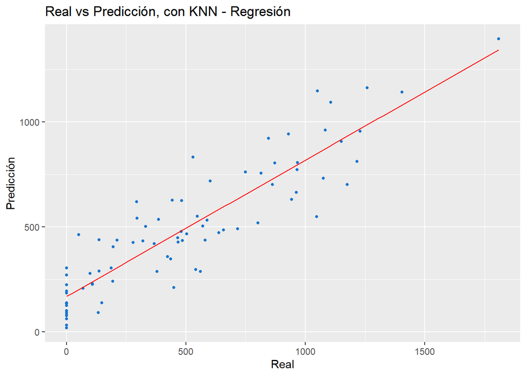

```r
g <- plot.real.prediccion(ttesting$Balance, prediccion1$prediction , modelo = "KNN - Regresión")

g + geom_smooth(method = lm, size = 0.4, color = "red", se = FALSE)
```

### Regresión Múltiple

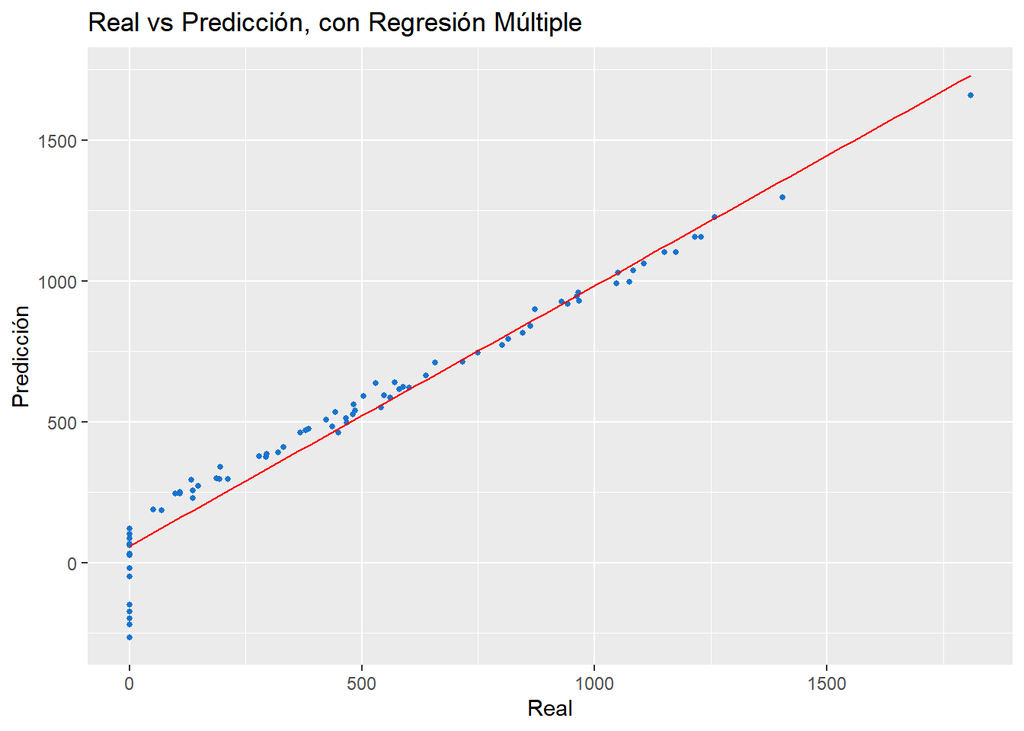

```r
g <- plot.real.prediccion(ttesting$Balance, prediccion2 , modelo = "Regresión Múltiple")
g + geom_smooth(method = lm, size = 0.4, color = "red", se = FALSE)
```

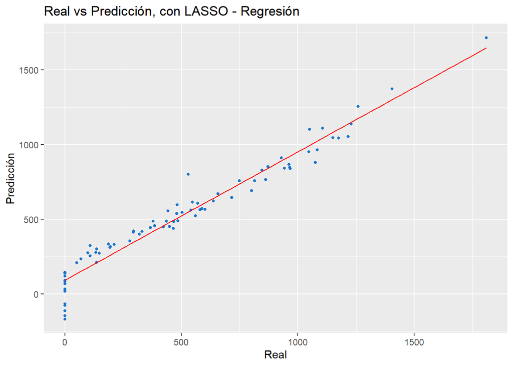

```r
g <- plot.real.prediccion(ttesting$Balance, prediccion3 , modelo = "LASSO - Regresión")
g + geom_smooth(method = lm, size = 0.4, color = "red", se = FALSE)
```

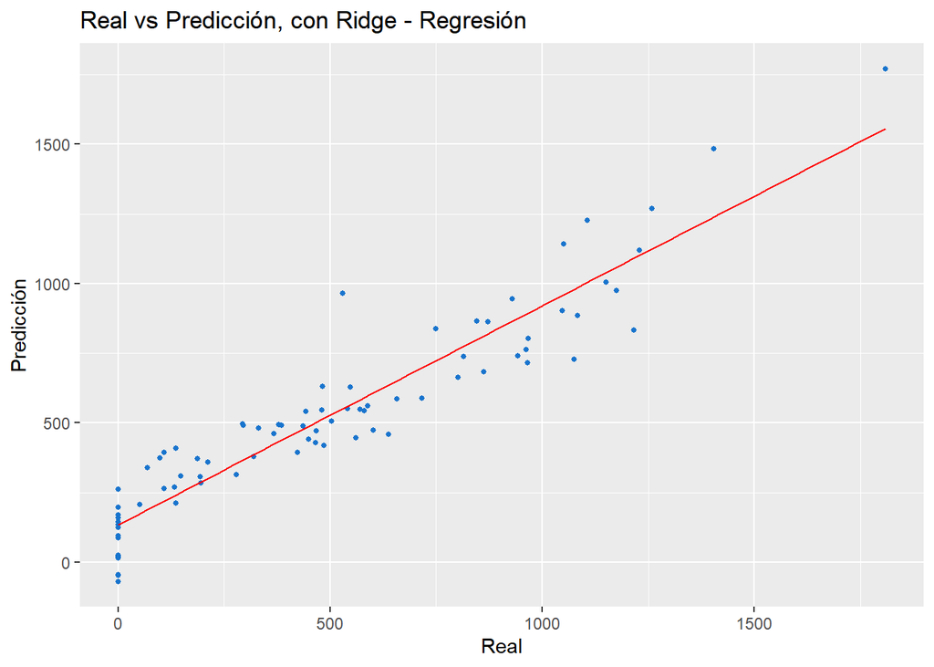

```r
g <- plot.real.prediccion(ttesting$Balance, prediccion4 , modelo = "Ridge - Regresión")
g + geom_smooth(method = lm, size = 0.4, color = "red", se = FALSE)
```

### Arboles

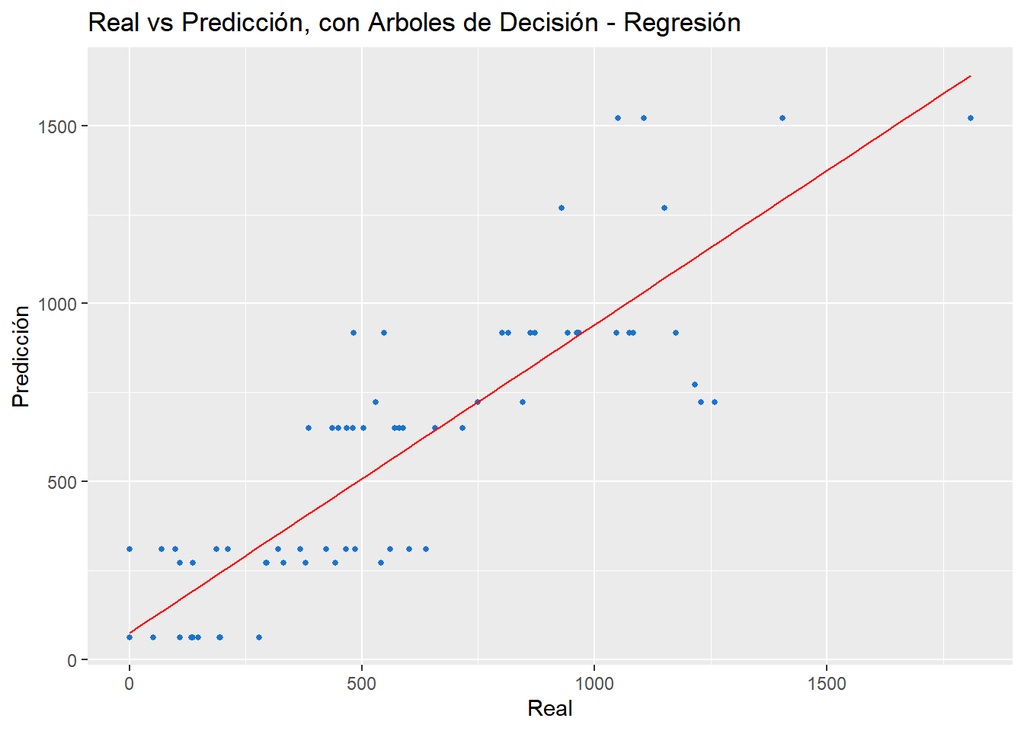

```r
g <- plot.real.prediccion(ttesting$Balance, prediccion5 , modelo = "Arboles de Decisión - Regresión")
g + geom_smooth(method = lm, size = 0.4, color = "red", se = FALSE)
```

### Bosques Aleatorios

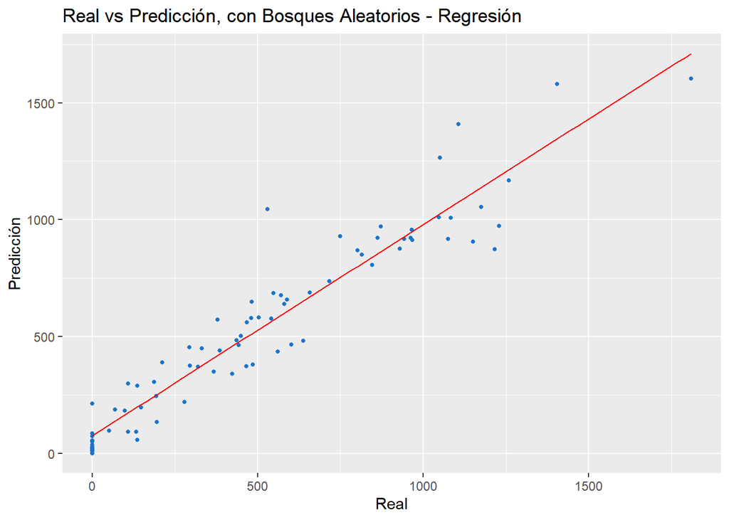

```r
g <- plot.real.prediccion(ttesting$Balance, prediccion6 , modelo = "Bosques Aleatorios - Regresión")
g + geom_smooth(method = lm, size = 0.4, color = "red", se = FALSE)
```